# Análisis Exploratorio de los Datos ESTADO DE SALUD

Alicia Perdices Guerra

21 de mayo, 2021

#### **1.ANÁLISIS EXPLORATORIO POR PAISES**

Se procede en primer lugar a cargar todos los archivos para poder realizar el análisis.

```r
estado<-read.csv("C:/temp/EstadoDeSalud_Sexo_clean.csv",sep= ",")
```

**1.1.- EN RELACIÓN CON EL ESTADO DE SALUD**

- **1.1.1 Análisis Descriptivo**

Se procede a realizar el análisis descriptivo:

```r
summary(estado)
```

```
##       TIME          GEO                UNIT               SEX
##  Min.   :2010   Length:990         Length:990         Length:990
##  1st Qu.:2012   Class :character   Class :character   Class :character
##  Median :2014   Mode  :character   Mode  :character   Mode  :character
##  Mean   :2014
##  3rd Qu.:2017
##  Max.   :2019
##    INDIC_HE             Value       Value_imp
##  Length:990         Min.   :50.60   Mode :logical
##  Class :character   1st Qu.:58.62   FALSE:972
##  Mode  :character   Median :62.20   TRUE :18
##                     Mean   :62.18
##                     3rd Qu.:65.00
##                     Max.   :76.10
```

Se filta el dataframe para que la variable GEO aparezcan solo los paises objeto de estudio.(Para cada archivo relacionado con El Estado de Salud (Años de vida Sana) y unificamos la información ). Además se selecciona la información relevante de la variable SEX (Males, Females).

```r
#Estado de Salud (Años de Vida Sana)
#=================================

estado_paises<- filter(estado,
              +(GEO!="European Union - 27 countries (from 2020)")&
             +(GEO!="European Union - 28 countries (2013-2020)"))

estado_males<-filter(estado_paises, SEX=="Males")
nrow(estado_males)
```

```
## [1] 310
```

```r
estado_females<-filter(estado_paises, SEX=="Females")
nrow(estado_females)
```

```
## [1] 310
```

```r
head(estado_females)
```

```
##   TIME                                              GEO UNIT     SEX
## 1 2010                                          Belgium Year Females
## 2 2010                                         Bulgaria Year Females
## 3 2010                                          Czechia Year Females
## 4 2010                                          Denmark Year Females
## 5 2010 Germany (until 1990 former territory of the FRG) Year Females
## 6 2010                                          Estonia Year Females
##                                        INDIC_HE Value Value_imp
## 1 Healthy life years in absolute value at birth  62.6     FALSE
## 2 Healthy life years in absolute value at birth  67.1     FALSE
## 3 Healthy life years in absolute value at birth  64.5     FALSE
## 4 Healthy life years in absolute value at birth  61.4     FALSE
## 5 Healthy life years in absolute value at birth  58.7     FALSE
## 6 Healthy life years in absolute value at birth  58.2     FALSE
```

```r
head(estado_males)
```

```
##   TIME                                              GEO UNIT   SEX
## 1 2010                                          Belgium Year Males
## 2 2010                                         Bulgaria Year Males
## 3 2010                                          Czechia Year Males
## 4 2010                                          Denmark Year Males
## 5 2010 Germany (until 1990 former territory of the FRG) Year Males
## 6 2010                                          Estonia Year Males
##                                        INDIC_HE Value Value_imp
## 1 Healthy life years in absolute value at birth  64.0     FALSE
## 2 Healthy life years in absolute value at birth  63.0     FALSE
## 3 Healthy life years in absolute value at birth  62.2     FALSE
## 4 Healthy life years in absolute value at birth  62.3     FALSE
## 5 Healthy life years in absolute value at birth  57.9     FALSE
## 6 Healthy life years in absolute value at birth  54.2     FALSE
```

Se crea un Dataframe con toda la información:

```r
year<-(estado_males$TIME)#Columna Year
country<-(estado_males$GEO)#Columna Paises


#Dataframe con toda la información relacionada
#con el Estado de Salud: Años con buen estado de salud
estado_salud<-data.frame("TIME"=year,"Pais"=country,
                     "Estado_males"=
                       estado_males$Value,
                     "Estado_females"=
                       estado_females$Value)

max(estado_salud$Estado_males)
```

```
## [1] 74
```

```r
max(estado_salud$Estado_females)
```

```
## [1] 76.1
```

```r
#Generamos el fichero filtrado para utilizarlo en el siguiente análisis.
write.csv(estado_salud, file="Estado_Salud_Analisis.csv", row.names = FALSE)
```

Se reescalan los datos:

```r
estado_salud["Estado_males_norm"]<-
  rescale(estado_salud$Estado_males, to=c(0,1))
estado_salud["Estado_females_norm"]<-
  rescale(estado_salud$Estado_females, to=c(0,1))
```

- **1.1.2 Visualización y Distribución de la información"**

Se visualiza las variable que nos dan información sobre el estado de salud realizada en función de TIME, y País.

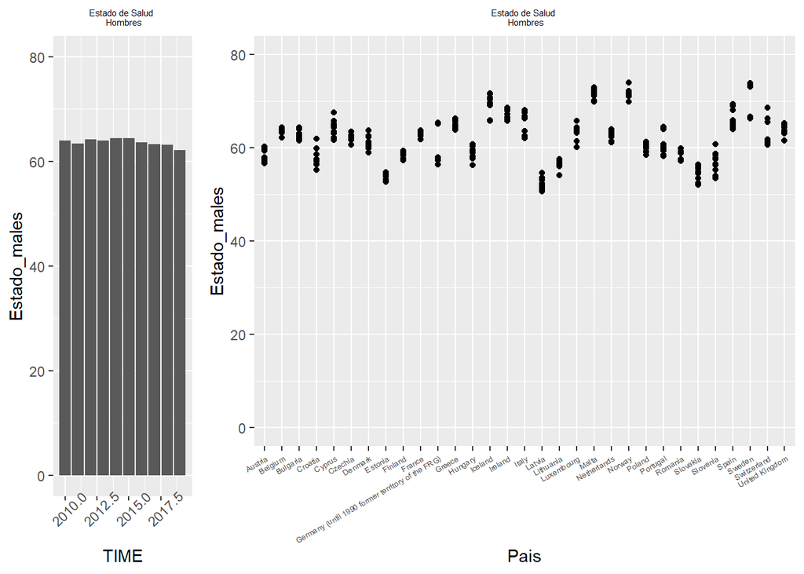

```r
#Estado de Salud_GRÁFICAS DE BARRAS
#=============================================================================
#Gráfica de barras de la información sobre el Estado de Salud en Hombres"
plot1=ggplot(data=estado_salud)+
  geom_col(aes(x=TIME,y=Estado_males))+
  theme(axis.text.x = element_text(angle = 45))+
  scale_y_continuous(limit=c(0,80))+
  ggtitle("Estado de Salud \n Hombres")+
  theme (plot.title = element_text(size=rel(0.5), hjust = 0.5))

#Gráfica de barras de la información sobre el Estado de Salud en Mujeres"
plot2=ggplot(data=estado_salud)+
  geom_col(aes(x=TIME,y=Estado_females))+
  theme(axis.text.x = element_text(size= 5,angle = 30,vjust=1,hjust = 1))+
  scale_y_continuous(limit=c(0,80))+
  ggtitle("Estado de salud \n Mujeres")+
  theme (plot.title = element_text(size=rel(0.5),hjust = 0.5))

#Estado de Salud_GRÁFICAS DE PUNTOS
#=============================================================================
#Gráfica de puntos de la información sobre el Estado de Salud en Hombres y Mujeres por Países"
plot3=ggplot(data=estado_salud)+
  geom_point(aes(x=Pais,y=Estado_males))+
  theme(axis.text.x = element_text(size= 5,angle = 30,vjust=1,hjust = 1))+
  scale_y_continuous(limit=c(0,80))+
  ggtitle("Estado de Salud \n Hombres")+
  theme (plot.title = element_text(size=rel(0.5),hjust=0.5))

#Gráfica de puntos de la información sobre la Detección del Cáncer de Cérvix Uterino por Países"
plot4=ggplot(data=estado_salud)+
  geom_point(aes(x=Pais,y=Estado_females))+
  theme(axis.text.x = element_text(size= 5,angle = 30,vjust=1,hjust = 1))+
  scale_y_continuous(limit=c(0,80))+
  ggtitle("Estado de salud \n Mujeres")+
  theme (plot.title = element_text(size=rel(0.5),hjust=0.5))

grid.arrange(plot1,plot3,widths=c(1,3),  ncol=2)
```

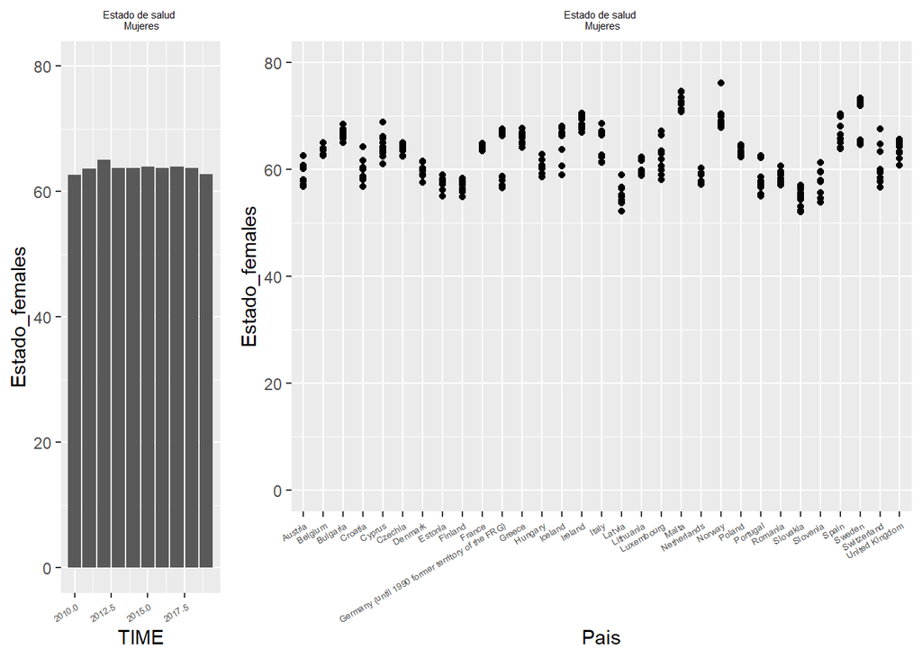

```r
grid.arrange(plot2,plot4,widths=c(1,3), ncol=2)
```

Se obtienen los 5 países con una mayor edad con un buen Estado de Salud.

- **Estado de Salud en Hombres**

```r
#########################################
#Para "Estado_males"                    #
#########################################

#Se filtra por Año

y_2010<-filter(estado_salud, TIME==2010)
y_2011<-filter(estado_salud, TIME==2011)
y_2012<-filter(estado_salud, TIME==2012)
y_2013<-filter(estado_salud, TIME==2013)
y_2014<-filter(estado_salud, TIME==2014)
y_2015<-filter(estado_salud, TIME==2015)
y_2016<-filter(estado_salud, TIME==2016)
y_2017<-filter(estado_salud, TIME==2017)
y_2018<-filter(estado_salud, TIME==2018)
y_2019<-filter(estado_salud, TIME==2019)

#Se ordena por "Estado_males"

estado_salud_5paises_2010<-y_2010[with(y_2010, order(-y_2010$Estado_males)),]
estado_salud_5paises_2011<-y_2011[with(y_2011, order(-y_2011$Estado_males)),]
estado_salud_5paises_2012<-y_2012[with(y_2012, order(-y_2012$Estado_males)),]
estado_salud_5paises_2013<-y_2013[with(y_2013, order(-y_2013$Estado_males)),]
estado_salud_5paises_2014<-y_2014[with(y_2014, order(-y_2014$Estado_males)),]
estado_salud_5paises_2015<-y_2015[with(y_2015, order(-y_2015$Estado_males)),]
estado_salud_5paises_2016<-y_2016[with(y_2016, order(-y_2016$Estado_males)),]
estado_salud_5paises_2017<-y_2017[with(y_2017, order(-y_2017$Estado_males)),]
estado_salud_5paises_2018<-y_2018[with(y_2018, order(-y_2018$Estado_males)),]
estado_salud_5paises_2019<-y_2019[with(y_2019, order(-y_2019$Estado_males)),]


#Se crea una tabla para cada año sobre el estado de salud en Hombres
#de los 5 Paises con un valor más alto.

kable(estado_salud_5paises_2010[0:5,c(2,3)], col.names = c("País","ES Hombres"),
      caption = "Países con mayor edad con buena salud en hombres en 2010")
```

Países con mayor edad con buena salud en hombres en 2010

|  | País | ES Hombres |
| --- | --- | --- |
| 18 | Malta | 70.1 |
| 29 | Norway | 69.8 |
| 28 | Iceland | 69.3 |
| 27 | Sweden | 66.6 |
| 8 | Greece | 66.1 |

```r
kable(estado_salud_5paises_2011[0:5,c(2,3)], col.names = c("País","ES Hombres"),
      caption = "Países con mayor edad con buena salud en hombres en 2011")
```

Países con mayor edad con buena salud en hombres en 2011

|  | País | ES Hombres |
| --- | --- | --- |
| 29 | Norway | 74.0 |
| 18 | Malta | 69.9 |
| 28 | Iceland | 69.1 |
| 27 | Sweden | 66.3 |
| 30 | Switzerland | 66.3 |

```r
kable(estado_salud_5paises_2012[0:5,c(2,3)], col.names = c("País","ES Hombres"),
      caption = "Países con mayor edad con buena salud en hombres en 2012")
```

Países con mayor edad con buena salud en hombres en 2012

|  | País | ES Hombres |
| --- | --- | --- |
| 29 | Norway | 71.9 |
| 18 | Malta | 71.5 |
| 28 | Iceland | 70.4 |
| 30 | Switzerland | 68.6 |
| 27 | Sweden | 66.4 |

```r
kable(estado_salud_5paises_2013[0:5,c(2,3)], col.names = c("País","ES Hombres"),
      caption = "Países con mayor edad con buena salud en hombres en 2013")
```

Países con mayor edad con buena salud en hombres en 2013

|  | País | ES Hombres |
| --- | --- | --- |
| 28 | Iceland | 71.7 |
| 18 | Malta | 71.6 |
| 29 | Norway | 71.0 |
| 27 | Sweden | 66.4 |
| 7 | Ireland | 65.7 |

```r
kable(estado_salud_5paises_2014[0:5,c(2,3)], col.names = c("País","ES Hombres"),
      caption = "Países con mayor edad con buena salud en hombres en 2014")
```

Países con mayor edad con buena salud en hombres en 2014

|  | País | ES Hombres |
| --- | --- | --- |
| 27 | Sweden | 73.0 |
| 18 | Malta | 72.3 |
| 29 | Norway | 72.2 |
| 28 | Iceland | 70.8 |
| 7 | Ireland | 66.3 |

```r
kable(estado_salud_5paises_2015[0:5,c(2,3)], col.names = c("País","ES Hombres"),
      caption = "Países con mayor edad con buena salud en hombres en 2015")
```

Países con mayor edad con buena salud en hombres en 2015

|  | País | ES Hombres |
| --- | --- | --- |
| 27 | Sweden | 73.1 |
| 18 | Malta | 72.6 |
| 29 | Norway | 71.8 |
| 28 | Iceland | 71.5 |
| 7 | Ireland | 66.5 |

```r
kable(estado_salud_5paises_2016[0:5,c(2,3)], col.names = c("País","ES Hombres"),
      caption = "Países con mayor edad con buena salud en hombres en 2016")
```

Países con mayor edad con buena salud en hombres en 2016

|  | País | ES Hombres |
| --- | --- | --- |
| 27 | Sweden | 73.0 |
| 29 | Norway | 72.0 |
| 18 | Malta | 71.1 |
| 28 | Iceland | 69.6 |
| 12 | Italy | 67.6 |

```r
kable(estado_salud_5paises_2017[0:5,c(2,3)], col.names = c("País","ES Hombres"),
      caption = "Países con mayor edad con buena salud en hombres en 2017")
```

Países con mayor edad con buena salud en hombres en 2017

|  | País | ES Hombres |
| --- | --- | --- |
| 27 | Sweden | 73.2 |
| 18 | Malta | 71.9 |
| 29 | Norway | 71.8 |
| 9 | Spain | 69.0 |
| 7 | Ireland | 67.9 |

```r
kable(estado_salud_5paises_2018[0:5,c(2,3)], col.names = c("País","ES Hombres"),
      caption = "Países con mayor edad con buena salud en hombres en 2018")
```

Países con mayor edad con buena salud en hombres en 2018

|  | País | ES Hombres |
| --- | --- | --- |
| 27 | Sweden | 73.7 |
| 18 | Malta | 71.9 |
| 29 | Norway | 71.7 |
| 7 | Ireland | 68.3 |
| 9 | Spain | 68.0 |

```r
kable(estado_salud_5paises_2019[0:5,c(2,3)], col.names = c("País","ES Hombres"),
      caption = "Países con mayor edad con buena salud en hombres en 2019")
```

Países con mayor edad con buena salud en hombres en 2019

|  | País | ES Hombres |
| --- | --- | --- |
| 27 | Sweden | 73.8 |
| 18 | Malta | 72.9 |
| 29 | Norway | 71.2 |
| 9 | Spain | 69.4 |
| 7 | Ireland | 68.6 |

A continuación, se aprupa toda la información por paises en una tabla:

```r
a1<-group_by(estado_salud,Pais)#Se agrupa por paises
#Se selecciona las variables Pais y Estado_males
a2<-select(a1,Pais:Estado_males)
#Se muestra la información por cada país, con Value=suma de
#los valores de cada país en los 10 años.
a3<-(summarize(a2,suma=sum(Estado_males)/10))
a4<-data.frame(a3)#Se convierte la información en un dataframe.
#Se ordena el DataFrame por la variable Suma de forma descendente.
a5<-a4[with(a4,order(-a4$suma)),]

#Se crea una tabla con toda la informacion
kable(a5[0:5,c(1,2)],
      col.names = c("País","ES Hombres"),
      caption = "Países con la mayor media en mayor Edad con buena salud en Hombres en 2010-2019")
```

Países con la mayor media en mayor Edad con buena salud en Hombres en 2010-2019

|  | País | ES Hombres |
| --- | --- | --- |
| 22 | Norway | 71.74 |
| 20 | Malta | 71.58 |
| 29 | Sweden | 70.55 |
| 14 | Iceland | 68.99 |
| 15 | Ireland | 66.85 |

- **Estado de Salud en Mujeres**

```r
#########################################
#Para "Estado_females"                    #
#########################################

#Se filtra por Año

y_2010<-filter(estado_salud, TIME==2010)
y_2011<-filter(estado_salud, TIME==2011)
y_2012<-filter(estado_salud, TIME==2012)
y_2013<-filter(estado_salud, TIME==2013)
y_2014<-filter(estado_salud, TIME==2014)
y_2015<-filter(estado_salud, TIME==2015)
y_2016<-filter(estado_salud, TIME==2016)
y_2017<-filter(estado_salud, TIME==2017)
y_2018<-filter(estado_salud, TIME==2018)
y_2019<-filter(estado_salud, TIME==2019)

#Se ordena por Estado_females"

estado_salud_5paises_2010<-y_2010[with(y_2010, order(-y_2010$Estado_females)),]
estado_salud_5paises_2011<-y_2011[with(y_2011, order(-y_2011$Estado_females)),]
estado_salud_5paises_2012<-y_2012[with(y_2012, order(-y_2012$Estado_females)),]
estado_salud_5paises_2013<-y_2013[with(y_2013, order(-y_2013$Estado_females)),]
estado_salud_5paises_2014<-y_2014[with(y_2014, order(-y_2014$Estado_females)),]
estado_salud_5paises_2015<-y_2015[with(y_2015, order(-y_2015$Estado_females)),]
estado_salud_5paises_2016<-y_2016[with(y_2016, order(-y_2016$Estado_females)),]
estado_salud_5paises_2017<-y_2017[with(y_2017, order(-y_2017$Estado_females)),]
estado_salud_5paises_2018<-y_2018[with(y_2018, order(-y_2018$Estado_females)),]
estado_salud_5paises_2019<-y_2019[with(y_2019, order(-y_2019$Estado_females)),]


#Se crea una tabla para cada año sobre el estado de salud en Mujeres
#de los 5 Paises con un valor más alto.

kable(estado_salud_5paises_2010[0:5,c(2,3)], col.names = c("País","ES Mujeres"),
      caption = "Países con mayor edad con buena salud en Mujeres en 2010")
```

[output not shown]

```r
kable(estado_salud_5paises_2011[0:5,c(2,3)], col.names = c("País","ES Mujeres"),
      caption = "Países con mayor edad con buena salud en Mujeres en 2011")
```

[output not shown]

```r
kable(estado_salud_5paises_2012[0:5,c(2,3)], col.names = c("País","ES Mujeres"),
      caption = "Países con mayor edad con buena salud en Mujeres en 2012")
```

[output not shown]

```r
kable(estado_salud_5paises_2013[0:5,c(2,3)], col.names = c("País","ES Mujeres"),
      caption = "Países con mayor edad con buena salud en Mujeres en 2013")
```

[output not shown]

```r
kable(estado_salud_5paises_2014[0:5,c(2,3)], col.names = c("País","ES Mujeres"),
      caption = "Países con mayor edad con buena salud en Mujeres en 2014")
```

[output not shown]

```r
kable(estado_salud_5paises_2015[0:5,c(2,3)], col.names = c("País","ES Mujeres"),
      caption = "Países con mayor edad con buena salud en Mujeres en 2015")
```

[output not shown]

```r
kable(estado_salud_5paises_2016[0:5,c(2,3)], col.names = c("País","ES Mujeres"),
      caption = "Países con mayor edad con buena salud en Mujeres en 2016")
```

[output not shown]

```r
kable(estado_salud_5paises_2017[0:5,c(2,3)], col.names = c("País","ES Mujeres"),
      caption = "Países con mayor edad con buena salud en Mujeres en 2017")
```

[output not shown]

```r
kable(estado_salud_5paises_2018[0:5,c(2,3)], col.names = c("País","ES Mujeres"),
      caption = "Países con mayor edad con buena salud en Mujeres en 2018")
```

[output not shown]

```r
kable(estado_salud_5paises_2019[0:5,c(2,3)], col.names = c("País","ES Mujeres"),
      caption = "Países con mayor edad con buena salud en Mujeres en 2019")
```

[output not shown]

A continuación, se aprupa toda la información por paises en una tabla:

```r
a1<-group_by(estado_salud,Pais)#Se agrupa por paises
#Se selecciona las variables Pais y Estado_females
a2<-select(a1,Pais:Estado_females)
#Se muestra la información por cada país, con Value=suma de
#los valores de cada país en los 10 años.
a3<-(summarize(a2,suma=sum(Estado_females)/10))
a4<-data.frame(a3)#Se convierte la información en un dataframe.
#Se ordena el DataFrame por la variable Suma de forma descendente.
a5<-a4[with(a4,order(-a4$suma)),]

#Se crea una tabla con toda la informacion
kable(a5[0:5,c(1,2)],
      col.names = c("País","ES Mujeres"),
      caption = "Países con la mayor media en mayor Edad con buena salud en Mujeres en 2010-2019")
```

Países con la mayor media en mayor Edad con buena salud en Mujeres en 2010-2019

|  | País | ES Mujeres |
| --- | --- | --- |
| 20 | Malta | 72.87 |
| 22 | Norway | 69.86 |
| 29 | Sweden | 69.50 |
| 15 | Ireland | 68.72 |
| 3 | Bulgaria | 66.61 |

- **1.1.3 Normalidad de la variable “Value (Estado_males,Estado_females)”**

Se comprueba con métodos visuales si la variable tiene una distribución normal.

**Estado_males**

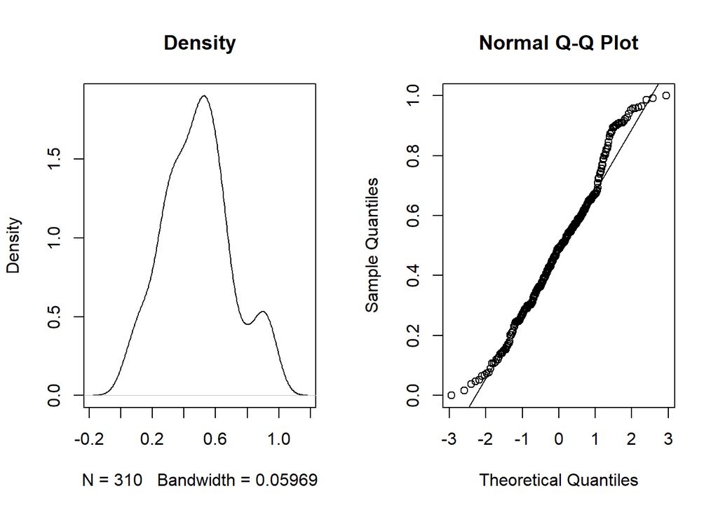

```r
par(mfrow=c(1,2))
plot(density(estado_salud$Estado_males_norm) ,main="Density")
qqnorm(estado_salud$Estado_males_norm)
qqline(estado_salud$Estado_males_norm)
```

Para estudiar si una muestra proviene de una población con distribución normal, se disponen de tres herramientas:

- Histograma o Densidad
- Gráficos cuantil cuantil (QQplot)
- Pruebas de hipótesis.

Si en la prueba de Densidad se observa sesgo hacia uno de los lados de la gráfica, sería indicio de que la muestra no proviene de una población normal.Si por otra parte, sí se observa simetría, **NO** se garantiza que la muestra provenga de una población normal. En estos casos sería necesario utilizar otras herramientas como **QQplot y pruebas de hipótesis**.

En la gráfica Densidad de la variable “Estado_males_norm”, se observa cierto sesgo hacia la derecha, aunque con una figura bastante aproximada a una curva normal. Se puede confirmar observando la gráfica QQplot en la que la línea que grafica qqline sirve de referencia para interpretar el gráfico. Si se tuviese una muestra distribuída normalmente, se esperaría que los puntos del gráfico quantil quantil estuviesen perfectamente alineados con la línea de referencia, y observamos que para este caso, “Estado_males_norm” se alinea bastante exceptuando los extremos.

Para confirmar, ya que en este caso existen dudas sobre la normalidad, se realizan las pruebas de hipótesis:

- $h_0: La muestra proviene de una población normal.
- $h_1: La muestra NO proviene de una población normal.

Se aplica la prueba Shapiro-Wilk:

```r
shapiro.test(estado_salud$Estado_males_norm)
```

```
##
##  Shapiro-Wilk normality test
##
## data:  estado_salud$Estado_males_norm
## W = 0.98481, p-value = 0.002326
```

Se observa un p-value pequeño, más pequeño que algunos niveles de significación ( como por ejemplo $alpha$=0.5) pero mayor que $alpha$=0.001 por lo que en este último caso no se rechaza la hipótesis nula y asumimos **Normalidad** en la muestra.

**Estado_females**

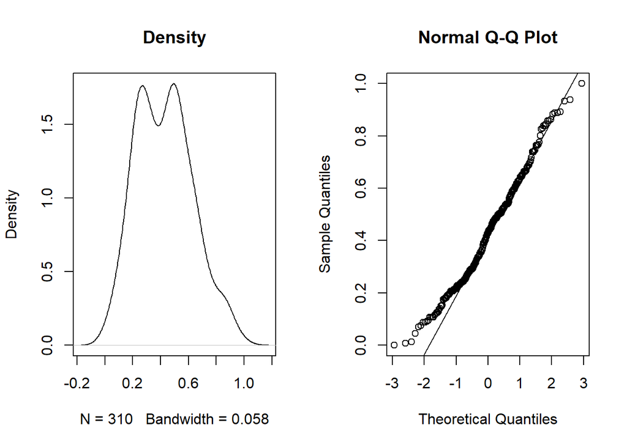

```r
par(mfrow=c(1,2))
plot(density(estado_salud$Estado_females_norm) ,main="Density")
qqnorm(estado_salud$Estado_females_norm)
qqline(estado_salud$Estado_females_norm)
```

En la gráfica Densidad de la variable “Estado_females_norm” , se observa una gráfica parecida a la obtenida anteriormente, existe cierto sesgo pero con una forma aproximada a una curva normal. Se puede confirmar observando la gráfica QQplot en la que la línea que grafica qqline sirve de referencia para interpretar el gráfico, se se alinea con los puntos de los valores de la variable “Estado_females_norm” exceptuando en los extremos.

Tras aplicar la prueba Shapiro-Wilk se comprueba:

```r
shapiro.test(estado_salud$Estado_females_norm)
```

```
##
##  Shapiro-Wilk normality test
##
## data:  estado_salud$Estado_females_norm
## W = 0.9835, p-value = 0.001247
```

Se observa un p-value pequeño, más pequeño que algunos niveles de significación ( como por ejemplo $alpha$=0.5) pero mayor que $alpha$=0.001 por lo que en este último caso no se rechaza la hipótesis nula y asumimos **Normalidad** en la muestra.